# INRODUCTION

Assignment 0

Section 1: Regression

Section 2: Classification

## Linear Algebra

**Linear algebra** is a widely used branch of discrete mathematics in machine learning specially in deep learning.

#### Mathematical objects :-

Scalars : Scalars are real numbers combination of which may represent vector or any other linar algebric object. They are written in italic with lowercase.

Vectors : An array of numbers(scalars) arranged in some order. Elements of vector can be thought as co-ordinates in space on different axes. '-' sign is used to index the complement of set.

Matrices : In simple words matrix is 2-D array with the combination of vectors. Usually they are given uppercase with bold tyepface. Each element of matrix can be found by ith and jth element combination. We can identify all the numbers with vertical coordinate i by writing a “:” for the horizontal coordinate.

Tensors : An array of numbers arranged on a regular grid with avariable number of axes is known as a tensor and represented as A.

#### Operations on objects :-

Transpose: Transpose of a **Matrix** is mirro image of matrix along its diagonal. Transpose of matrix A is represented as A^T.

Broadcasting: Addition of matrix with vectors is possible in linear algebra like **C= A + b** where **b** is vector which is added to each row. Such implicit copying of **b** to many location is broadcasting.

Multiplication: Matrix multiplication is one of the important operation used in linear algebra. A X B = C where A has m X n shape and B has n X p shape then new C matrix will have m X p shape.

**Properties of matrix multiplication**

Distributive : $A(B + C) = AB + AC$ Associative : $A(BC) = (AB)C$ Not commutative : $AB = BA$ may not be always true.

**Identity and Inverse matrix**: Identity matrix is a matrix which when divided by with any matrix does not change denoted by *I* Inverse matrix is nothing but when A matrix is multiplied by its transpose gives answer as identity matrix.

**Linear dependence and span**: If there are more than one possible solution , to analyze them we can find how many ways are there from origin in order to travel different directions determining how may ways are there to reach b. *x* specifies the directions. such kind of operations are linear combination. The span of a set of vectors is the set of all points obtainable by linear combinationof the original vectors.

**Norms** : In machine learning Norms are used to measure the size of the vectors. One norm that commonly arises in machine learning is the $L^∞$ norm,also known as themax norm. This norm simpliﬁes to the absolute value of the element with the largest magnitude in the vector. $||x||∞= maxi|xi$

**Eigendecomposition**: Matrix decomposition where matrix is divided into eigenvectors and eigenvalues is called as eigedecomposition.

**Single value decomposition**: Another way to divide matrix is single value decomposition where matrix is divided into singular vectors and singular values.

**Principal Component Analysis**: The central idea of principal component analysis (PCA) is to decrease the dimensionality of a data set consisting of a big number of interrelated variables, while maintaining as much as reasonable of the variation present in the data set. This is accomplished by changing to a new set of variables, the principal components (PCs), which are uncorrelated, and which are ordered so that the first few retain most of the variation existing in all of the primary variables.

## Probability Theory

**Machine learning** should always deal with uncertainties and stochasticity, and hence studying probability theory is important part. There are three possible sources of uncertainty:

```
1. Inherent stochasticity - This is type of probability where we assume some hypothesis in a random order

2. Incomplete observability - Incomplete observability is the one where outcome of the task is known but we can not observe all variables associated with it.
3. Incomplete modeling - When we discard some variables after observation , those discared variables become uncertainity in predictions which is due to incomplete modeling.
```

Frequentist probability and Baysian probability are types of probability based on absolute certainity. If we list several properties that we expect common sense reasoning about uncertainty to have, then the only way to satisfy those properties is to treat Bayesian probabilities as behaving exactly the same as frequentist probabilities.

Random variables are variables which can take different values and can be discrete or continuos. Discrete Variables are like points plotted on charts whereas continuos variables can be plotted as a line. Discrete variables are countable and continuos are not countable.

Chain rule of conditional probability :

For 2 variables: P(A,B) = p(A|B) p(B)

For 3 variables: P(A,B,C) = P(A| B,C) P(B,C) = P(A|B,C) P(B|C) P(C)

and in general to n variables: P(A1, A2, ..., An) = P(A1| A2, ..., An) P(A2| A3, ..., An) P(An-1|An) P(An)

Common probability distribution:

1.Bernoulli Distribution- The Bernoulli distribution is a discrete distribution having two possible outcomes labelled by n=0 and n=1 in which n=1 ("success") occurs with probability p and n=0 ("failure") occurs with probability q=1-p, where 0<p<1. It therefore has probability density function. The Bernoulli distribution is the simplest discrete distribution, and it the building block for other more complicated discrete distributions.

2.Multinoulli Distribution- Themultinoulli, orcategorical,distributionis a distribution over a single dis-crete variable withkdiﬀerent states, wherekis ﬁnite.

3.Gaussian Distribution- The Gaussian distribution is a continuous function which approximates the exact binomial distribution of events. The Gaussian distribution shown is normalized so that the sum over all values of x gives a probability of 1.

4.Exponential and Laplace Distributions- In the context of deep learning, we often want to have a probability distribution with a sharp point atx= 0. To accomplish this, we can use the exponential distribution: $p(x; λ) = λ1x≥0exp (−λx)$.

Bay's rule : We often ﬁnd ourselves in a situation where we knowP(y | x) and need to knowP(x | y). Fortunately, if we also knowP(x), we can compute the desired quantityusing Bayes’ rule: $P (x | y) =P (x)P (y | x)/P (y).

```python
#Import libraries

import pandas as pd
import numpy as np
import matplotlib.pyplot as plt

import seaborn as sns
sns.set(style="darkgrid")
```

# Section 1 - Regression

## 1.1 Introduction of data for regression & source

*This dataset includes a hourly/daily summary for Szeged, Hungary area, between 2006 and 2016.*

*Data available in the hourly response:*

```
.time
.summary
.precipType
.temperature
.apparentTemperature
.humidity
.windSpeed
.windBearing
.visibility
.loudCover
.pressure
```

## Source of the data

https://www.kaggle.com/budincsevity/szeged-weather

## 1.2 Reading the data

```python
df_reg = pd.read_csv(r'C:\sem2\ML\Assignment0\szeged-weather\weatherHistory.csv',encoding ='latin-1')
```

**Print top few rows**

```python
df_reg.head()
```

|  | Formatted Date | Summary | Precip Type | Temperature (C) | Apparent Temperature (C) | Humidity | Wind Speed (km/h) | Wind Bearing (degrees) | Visibility (km) | Loud Cover | Pressure (millibars) | Daily Summary |
| --- | --- | --- | --- | --- | --- | --- | --- | --- | --- | --- | --- | --- |
| 0 | 2006-04-01 00:00:00.000 +0200 | Partly Cloudy | rain | 9.472222 | 7.388889 | 0.89 | 14.1197 | 251.0 | 15.8263 | 0.0 | 1015.13 | Partly cloudy throughout the day. |
| 1 | 2006-04-01 01:00:00.000 +0200 | Partly Cloudy | rain | 9.355556 | 7.227778 | 0.86 | 14.2646 | 259.0 | 15.8263 | 0.0 | 1015.63 | Partly cloudy throughout the day. |
| 2 | 2006-04-01 02:00:00.000 +0200 | Mostly Cloudy | rain | 9.377778 | 9.377778 | 0.89 | 3.9284 | 204.0 | 14.9569 | 0.0 | 1015.94 | Partly cloudy throughout the day. |
| 3 | 2006-04-01 03:00:00.000 +0200 | Partly Cloudy | rain | 8.288889 | 5.944444 | 0.83 | 14.1036 | 269.0 | 15.8263 | 0.0 | 1016.41 | Partly cloudy throughout the day. |
| 4 | 2006-04-01 04:00:00.000 +0200 | Mostly Cloudy | rain | 8.755556 | 6.977778 | 0.83 | 11.0446 | 259.0 | 15.8263 | 0.0 | 1016.51 | Partly cloudy throughout the day. |

**Print names of columns**

```python
df_reg.columns
```

```
Index(['Formatted Date', 'Summary', 'Precip Type', 'Temperature (C)',
       'Apparent Temperature (C)', 'Humidity', 'Wind Speed (km/h)',
       'Wind Bearing (degrees)', 'Visibility (km)', 'Loud Cover',
       'Pressure (millibars)', 'Daily Summary'],
      dtype='object')
```

```python
df_reg.isnull().sum()
```

```
Formatted Date                0
Summary                       0
Precip Type                 517
Temperature (C)               0
Apparent Temperature (C)      0
Humidity                      0
Wind Speed (km/h)             0
Wind Bearing (degrees)        0
Visibility (km)               0
Loud Cover                    0
Pressure (millibars)          0
Daily Summary                 0
dtype: int64
```

## 1.3 Preprocessing of the data

**Inspecting all variables**

**Variable Formatted Date**

```python
df_reg['Formatted Date'].head()
```

```
0    2006-04-01 00:00:00.000 +0200
1    2006-04-01 01:00:00.000 +0200
2    2006-04-01 02:00:00.000 +0200
3    2006-04-01 03:00:00.000 +0200
4    2006-04-01 04:00:00.000 +0200
Name: Formatted Date, dtype: object
```

**Formatted date is not in better format. Let us convert it to format 'YYYY-MM-DD'**

```python
df_reg["Formatted Date"]=df_reg["Formatted Date"].str.split(" ", n = 1, expand = True)
```

```python
df_reg['Formatted Date'].describe()
```

```
count          96453
unique          4018
top       2010-08-02
freq              48
Name: Formatted Date, dtype: object
```

**Variable Summary**

```python
df_reg.Summary.head()
```

```
0    Partly Cloudy
1    Partly Cloudy
2    Mostly Cloudy
3    Partly Cloudy
4    Mostly Cloudy
Name: Summary, dtype: object
```

```python
df_reg.Summary.describe()
```

```
count             96453
unique               27
top       Partly Cloudy
freq              31733
Name: Summary, dtype: object
```

```python
df_reg.Summary.unique()
```

```
array(['Partly Cloudy', 'Mostly Cloudy', 'Overcast', 'Foggy',
       'Breezy and Mostly Cloudy', 'Clear', 'Breezy and Partly Cloudy',
       'Breezy and Overcast', 'Humid and Mostly Cloudy',
       'Humid and Partly Cloudy', 'Windy and Foggy', 'Windy and Overcast',
       'Breezy and Foggy', 'Windy and Partly Cloudy', 'Breezy',
       'Dry and Partly Cloudy', 'Windy and Mostly Cloudy',
       'Dangerously Windy and Partly Cloudy', 'Dry', 'Windy',
       'Humid and Overcast', 'Light Rain', 'Drizzle', 'Windy and Dry',
       'Dry and Mostly Cloudy', 'Breezy and Dry', 'Rain'], dtype=object)
```

**Variable Precip Type**

```python
df_reg['Precip Type'].head()
```

```
0    rain
1    rain
2    rain
3    rain
4    rain
Name: Precip Type, dtype: object
```

```python
df_reg['Precip Type'].describe()
```

```
count     95936
unique        2
top        rain
freq      85224
Name: Precip Type, dtype: object
```

```python
df_reg['Precip Type'].unique()
```

```
array(['rain', 'snow', nan], dtype=object)
```

**Variable Temperature (C)**

```python
df_reg['Temperature (C)'].head()
```

```
0    9.472222
1    9.355556
2    9.377778
3    8.288889
4    8.755556
Name: Temperature (C), dtype: float64
```

```python
df_reg['Temperature (C)'].describe()
```

```
count    96453.000000
mean        11.932678
std          9.551546
min        -21.822222
25%          4.688889
50%         12.000000
75%         18.838889
max         39.905556
Name: Temperature (C), dtype: float64
```

```python
df_reg['Temperature (C)'].min()
```

```
-21.822222222222226
```

```python
df_reg['Temperature (C)'].max()
```

```
39.90555555555555
```

**Variable Apparent Temperature (C)**

```python
df_reg['Apparent Temperature (C)'].head()
```

```
0    7.388889
1    7.227778
2    9.377778
3    5.944444
4    6.977778
Name: Apparent Temperature (C), dtype: float64
```

```python
df_reg['Apparent Temperature (C)'].describe()
```

```
count    96453.000000
mean        10.855029
std         10.696847
min        -27.716667
25%          2.311111
50%         12.000000
75%         18.838889
max         39.344444
Name: Apparent Temperature (C), dtype: float64
```

**Variable Humidity**

```python
df_reg.Humidity.head()
```

```
0    0.89
1    0.86
2    0.89
3    0.83
4    0.83
Name: Humidity, dtype: float64
```

```python
df_reg.Humidity.describe()
```

```
count    96453.000000
mean         0.734899
std          0.195473
min          0.000000
25%          0.600000
50%          0.780000
75%          0.890000
max          1.000000
Name: Humidity, dtype: float64
```

**Variable Wind Speed (km/h)**

```python
df_reg['Wind Speed (km/h)'].head()
```

```
0    14.1197
1    14.2646
2     3.9284
3    14.1036
4    11.0446
Name: Wind Speed (km/h), dtype: float64
```

```python
df_reg['Wind Speed (km/h)'].describe()
```

```
count    96453.000000
mean        10.810640
std          6.913571
min          0.000000
25%          5.828200
50%          9.965900
75%         14.135800
max         63.852600
Name: Wind Speed (km/h), dtype: float64
```

**Variable Wind Bearing (degrees)**

```python
df_reg['Wind Bearing (degrees)'].head()
```

```
0    251.0
1    259.0
2    204.0
3    269.0
4    259.0
Name: Wind Bearing (degrees), dtype: float64
```

```python
df_reg['Wind Bearing (degrees)'].describe()
```

```
count    96453.000000
mean       187.509232
std        107.383428
min          0.000000
25%        116.000000
50%        180.000000
75%        290.000000
max        359.000000
Name: Wind Bearing (degrees), dtype: float64
```

**Variable Visibility (km)**

```python
df_reg['Visibility (km)'].head()
```

```
0    15.8263
1    15.8263
2    14.9569
3    15.8263
4    15.8263
Name: Visibility (km), dtype: float64
```

```python
df_reg['Visibility (km)'].describe()
```

```
count    96453.000000
mean        10.347325
std          4.192123
min          0.000000
25%          8.339800
50%         10.046400
75%         14.812000
max         16.100000
Name: Visibility (km), dtype: float64
```

**Variable Loud Cover**

```python
df_reg['Loud Cover'].head()
```

```
0    0.0
1    0.0
2    0.0
3    0.0
4    0.0
Name: Loud Cover, dtype: float64
```

```python
df_reg['Loud Cover'].describe()
```

```
count    96453.0
mean         0.0
std          0.0
min          0.0
25%          0.0
50%          0.0
75%          0.0
max          0.0
Name: Loud Cover, dtype: float64
```

**Above variable only has 0 as value. It it of no use hence removing it**

```python
df_reg=df_reg.drop(columns=['Loud Cover'])
```

**Variable Pressure (millibars)**

```python
df_reg['Pressure (millibars)'].head()
```

```
0    1015.13
1    1015.63
2    1015.94
3    1016.41
4    1016.51
Name: Pressure (millibars), dtype: float64
```

```python
df_reg['Pressure (millibars)'].describe()
```

```
count    96453.000000
mean      1003.235956
std        116.969906
min          0.000000
25%       1011.900000
50%       1016.450000
75%       1021.090000
max       1046.380000
Name: Pressure (millibars), dtype: float64
```

**Variable Daily Summary**

```python
df_reg['Daily Summary'].head()
```

```
0    Partly cloudy throughout the day.
1    Partly cloudy throughout the day.
2    Partly cloudy throughout the day.
3    Partly cloudy throughout the day.
4    Partly cloudy throughout the day.
Name: Daily Summary, dtype: object
```

```python
df_reg['Daily Summary'].describe()
```

```
count                                 96453
unique                                  214
top       Mostly cloudy throughout the day.
freq                                  20085
Name: Daily Summary, dtype: object
```

## 1.4 Visualization of the data

### 1. Correlation Diagram between different features

```python
corr = df_reg.corr()
```

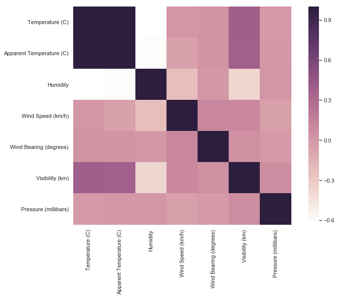

```python
plt.figure(figsize=(12,8))
cmap = sns.cubehelix_palette(light=1, as_cmap=True)
sns.heatmap(corr,cmap=cmap, square=True)
```

**Observations:**

- Figure is symmetric along the diagonal.
- Correlation matrix is plotted using correlation coeficient.
- Relation between Humidity and Temperature or Apparent Temperature shows negative relation.
- Temperature and apparent temperature are strongly co-related.

### 2. Average Temperature variation in 2006 per month

```python
df_temp = df_reg.copy()
df_temp["Formatted Date"]= (df_temp["Formatted Date"].str.rsplit("-", n = 1, expand = True))
```

```python
df_temp["Formatted Date"].head()
```

```
0    2006-04
1    2006-04
2    2006-04
3    2006-04
4    2006-04
Name: Formatted Date, dtype: object
```

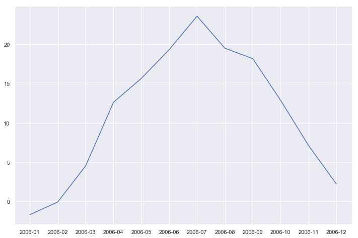

```python
plt.figure(figsize=(12,8))
df_temp = df_temp.sort_values(['Formatted Date'])

df_temp = (df_temp.head(8760))
df_temp= df_temp.sort_values(['Formatted Date'])
df_temp = (df_temp.groupby('Formatted Date', as_index=False)['Temperature (C)'].mean())
plt.plot(df_temp["Formatted Date"], df_temp["Temperature (C)"])
```

**Observations:**

### 3. Summary Count plot

```python
df_reg.describe()
```

|  | Temperature (C) | Apparent Temperature (C) | Humidity | Wind Speed (km/h) | Wind Bearing (degrees) | Visibility (km) | Pressure (millibars) |
| --- | --- | --- | --- | --- | --- | --- | --- |
| count | 96453.000000 | 96453.000000 | 96453.000000 | 96453.000000 | 96453.000000 | 96453.000000 | 96453.000000 |
| mean | 11.932678 | 10.855029 | 0.734899 | 10.810640 | 187.509232 | 10.347325 | 1003.235956 |
| std | 9.551546 | 10.696847 | 0.195473 | 6.913571 | 107.383428 | 4.192123 | 116.969906 |
| min | -21.822222 | -27.716667 | 0.000000 | 0.000000 | 0.000000 | 0.000000 | 0.000000 |
| 25% | 4.688889 | 2.311111 | 0.600000 | 5.828200 | 116.000000 | 8.339800 | 1011.900000 |
| 50% | 12.000000 | 12.000000 | 0.780000 | 9.965900 | 180.000000 | 10.046400 | 1016.450000 |
| 75% | 18.838889 | 18.838889 | 0.890000 | 14.135800 | 290.000000 | 14.812000 | 1021.090000 |
| max | 39.905556 | 39.344444 | 1.000000 | 63.852600 | 359.000000 | 16.100000 | 1046.380000 |

```python
df_month= df_reg[(df_reg['Formatted Date'] > '2015')]
```

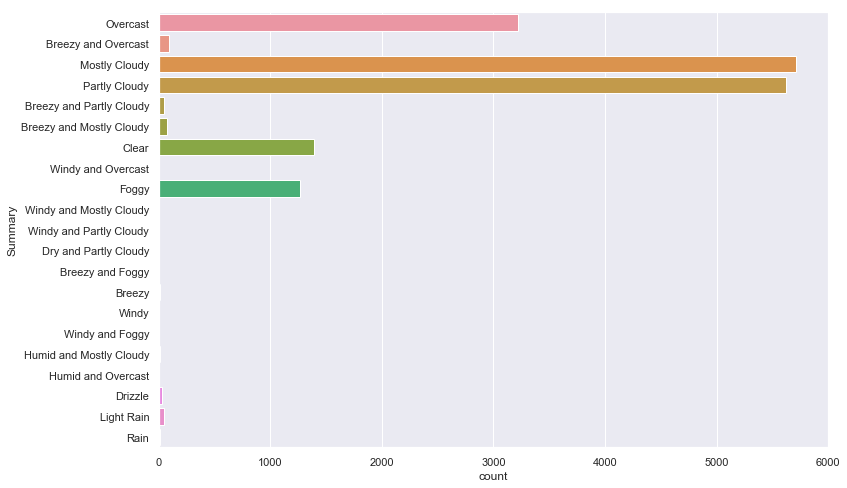

```python
plt.figure(figsize=(12,8))
sns.countplot(y=df_month['Summary'])
```

**Observations:**

```python
df_precip = df_month.dropna(subset=['Precip Type'])
df_precip.isnull().sum()
```

```
Formatted Date              0
Summary                     0
Precip Type                 0
Temperature (C)             0
Apparent Temperature (C)    0
Humidity                    0
Wind Speed (km/h)           0
Wind Bearing (degrees)      0
Visibility (km)             0
Pressure (millibars)        0
Daily Summary               0
dtype: int64
```

### 4. Temperature and Humidity comparison over a day in 2006

```python
df1 = pd.read_csv(r'C:\sem2\ML\Assignment0\szeged-weather\weatherHistory.csv',encoding ='latin-1')
df1["Formatted Date"]=df1["Formatted Date"].str.split("+", n = 1, expand = True)
df1["Formatted Date"]=df1["Formatted Date"].str.split(":", n = 1, expand = True)
df1= df1[(df1['Formatted Date'] < '2006-01-02')]
df1["Formatted Date"]=(df1["Formatted Date"].str.split(" ", n = 1, expand = True))[1]
df1= df1.sort_values(['Formatted Date'])
```

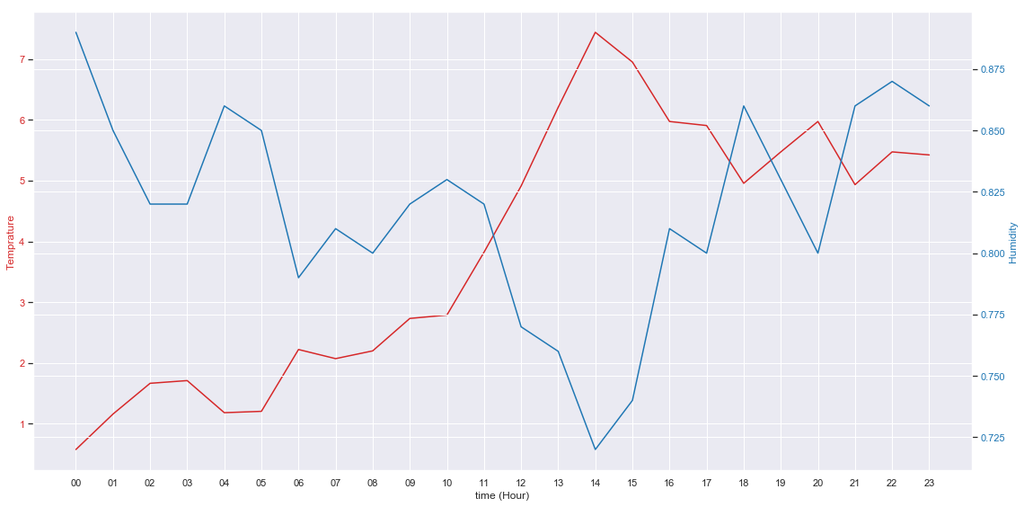

```python
t = df1['Formatted Date']
data1 = df1['Temperature (C)']
data2 = df1['Humidity']

fig, ax1 = plt.subplots(figsize=(16,8))

color = 'tab:red'
ax1.set_xlabel('time (Hour)')
ax1.set_ylabel('Temprature', color=color)
ax1.plot(t, data1, color=color)

ax1.tick_params(axis='y', labelcolor=color)

ax2 = ax1.twinx()  # instantiate a second axes that shares the same x-axis

color = 'tab:blue'
ax2.set_ylabel('Humidity', color=color)  # we already handled the x-label with ax1
ax2.plot(t, data2, color=color)
ax2.tick_params(axis='y', labelcolor=color)
fig.tight_layout()  # otherwise the right y-label is slightly clipped
plt.show()
```

**Observations:**

- As temperature increases , humidity is decreasing in a day per hour.

### 5. Temperature Distribution

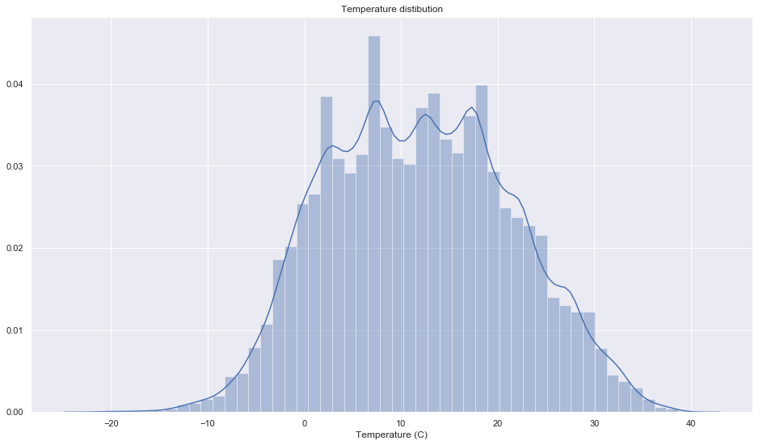

```python
plt.figure(figsize = (16, 9))
plt.title('Temperature distibution')
sns.distplot(df_reg['Temperature (C)'])
plt.show()
```

**Observations:**

- Standard deviation between 0 and 20 is more in temperature feature.

### 6. Yearwise visibility ratio in rain and snowy weather

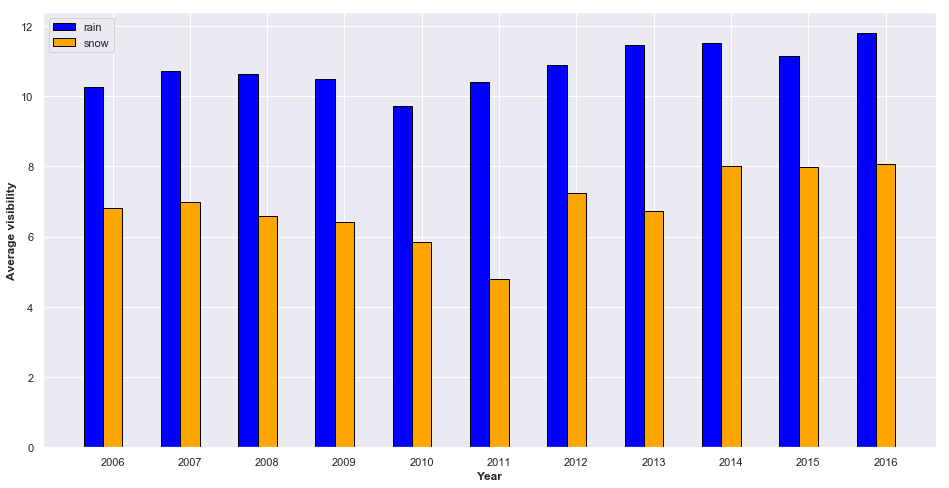

```python
df_yearwise = df_reg.copy()
df_yearwise['Formatted Date'] = pd.DatetimeIndex(df_yearwise['Formatted Date']).year
df_grp= df_yearwise.groupby(['Formatted Date','Precip Type']).mean().reset_index()


rain_visibility = list(df_grp[(df_grp['Precip Type'] == 'rain')]['Visibility (km)'])
snow_visibility = list(df_grp[(df_grp['Precip Type'] == 'snow')]['Visibility (km)'])
years = df_grp['Formatted Date'].unique()
barWidth = 0.25
rain = np.arange(len(rain_visibility))
snow= [x + barWidth for x in rain]
plt.figure(figsize = (16, 8))
plt.bar(rain, rain_visibility, color='blue', width=barWidth, edgecolor='black', label='rain')
plt.bar(snow, snow_visibility, color='orange', width=barWidth, edgecolor='black', label='snow')
###
plt.xlabel('Year', fontweight='bold')
plt.xticks([r + barWidth for r in range(len(rain_visibility))], years)
plt.ylabel('Average visibility', fontweight='bold')
###
plt.legend()
plt.show()
```

**Observations:**

### 7. Yearwise temperature comparison

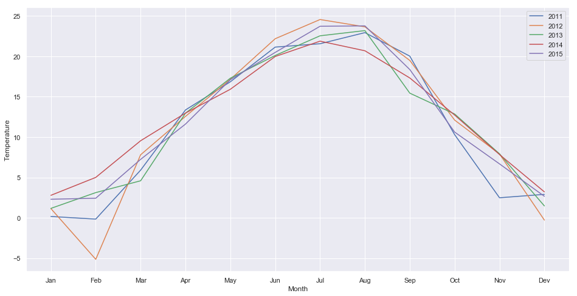

```python
df_month = df_reg.copy()
df_month['year'] = pd.DatetimeIndex(df_month['Formatted Date']).year
df_month['month'] = pd.DatetimeIndex(df_month['Formatted Date']).month
df_month = df_month.drop(columns=['Formatted Date'])
df_month.head()
df_m = df_month.groupby(['year','month']).mean().reset_index()
# to get 5 years data from 2010 -2016
df_m = df_m[(df_m['year'] > 2010)]
list_temp = list(df_m['Temperature (C)'])
x = ['Jan','Feb','Mar','Apr','May','Jun','Jul','Aug','Sep','Oct','Nov','Dev']
c= 0
temp = []
plt.figure(figsize = (16, 8))
for i in list_temp:
    if c <12:
        temp.append(i)
        c = c+1
    else:
        plt.plot(x,temp)
        c= 0
        temp = []
        temp.append(i)
        c= c+1
plt.legend(['2011','2012','2013','2014','2015','2016'])
plt.xlabel('Month')
plt.ylabel('Temperature')
```

**Observations:**

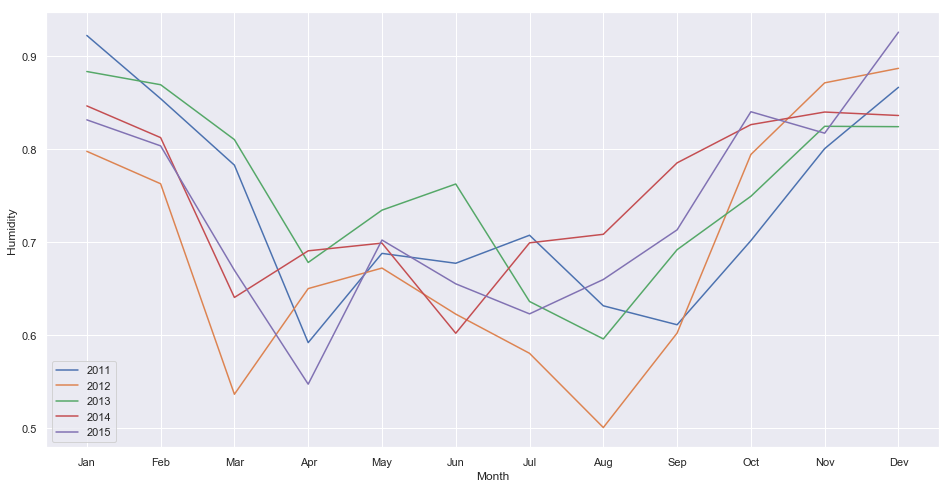

```python
df_month = df_reg.copy()
df_month['year'] = pd.DatetimeIndex(df_month['Formatted Date']).year
df_month['month'] = pd.DatetimeIndex(df_month['Formatted Date']).month
df_month = df_month.drop(columns=['Formatted Date'])
df_month.head()
df_m = df_month.groupby(['year','month']).mean().reset_index()
# to get 5 years data from 2010 -2016
df_m = df_m[(df_m['year'] > 2010)]
list_temp = list(df_m['Humidity'])
x = ['Jan','Feb','Mar','Apr','May','Jun','Jul','Aug','Sep','Oct','Nov','Dev']
c= 0
temp = []
plt.figure(figsize = (16, 8))
for i in list_temp:
    if c <12:
        temp.append(i)
        c = c+1
    else:
        plt.plot(x,temp)
        c= 0
        temp = []
        temp.append(i)
        c= c+1
plt.legend(['2011','2012','2013','2014','2015','2016'])
plt.xlabel('Month')
plt.ylabel('Humidity')
```

**Observations:**

- This graph shows that humidity variation patterns from year 2011 to 2015
- Towards start and end of the year humidity is high compared to others months.

## 1.5 Preliminary Observation

[output not shown]

# Section 2 - Classification

## 2.1 Introduction of data classification & source

### Black Friday shopping data from retail store

*This dataset consists of 550 000 observations of the transactions made in a retail store. It contains different types of variables like User id, Product Id, customer age group, city category, stay in current city year, martital status of the customer etc. This data set aims to predict patterns between different features.*

## Source of the data

https://www.kaggle.com/mehdidag/black-friday

## 2.2 Reading Data

### Reading data using pandas read_csv function

```python
df = pd.read_csv(r'C:\sem2\ML\Assignment0\black-friday\BlackFriday.csv',encoding ='latin-1')
```

### Print data few top rows

```python
df.head()
```

|  | User_ID | Product_ID | Gender | Age | Occupation | City_Category | Stay_In_Current_City_Years | Marital_Status | Product_Category_1 | Product_Category_2 | Product_Category_3 | Purchase |
| --- | --- | --- | --- | --- | --- | --- | --- | --- | --- | --- | --- | --- |
| 0 | 1000001 | P00069042 | F | 0-17 | 10 | A | 2 | 0 | 3 | NaN | NaN | 8370 |
| 1 | 1000001 | P00248942 | F | 0-17 | 10 | A | 2 | 0 | 1 | 6.0 | 14.0 | 15200 |
| 2 | 1000001 | P00087842 | F | 0-17 | 10 | A | 2 | 0 | 12 | NaN | NaN | 1422 |
| 3 | 1000001 | P00085442 | F | 0-17 | 10 | A | 2 | 0 | 12 | 14.0 | NaN | 1057 |
| 4 | 1000002 | P00285442 | M | 55+ | 16 | C | 4+ | 0 | 8 | NaN | NaN | 7969 |

### Print shape of the dataframe

**Dimension of the data**

```python
df.shape
```

```
(537577, 12)
```

**Print names of columns**

```python
df.columns
```

```
Index(['User_ID', 'Product_ID', 'Gender', 'Age', 'Occupation', 'City_Category',
       'Stay_In_Current_City_Years', 'Marital_Status', 'Product_Category_1',
       'Product_Category_2', 'Product_Category_3', 'Purchase'],
      dtype='object')
```

```python
City_category = {'A':'County','B':'City','C':'Town'}
```

## 2.3 Preprocessing of the data

### Describing each column of data

### Variable User_ID

```python
df.User_ID.head()
```

```
0    1000001
1    1000001
2    1000001
3    1000001
4    1000002
Name: User_ID, dtype: int64
```

```python
df.User_ID.describe()
```

```
count    5.375770e+05
mean     1.002992e+06
std      1.714393e+03
min      1.000001e+06
25%      1.001495e+06
50%      1.003031e+06
75%      1.004417e+06
max      1.006040e+06
Name: User_ID, dtype: float64
```

### Variable Product_ID

```python
df.Product_ID.describe()
```

```
count        537577
unique         3623
top       P00265242
freq           1858
Name: Product_ID, dtype: object
```

### Variable Gender

```python
df.Gender.describe()
```

```
count     537577
unique         2
top            M
freq      405380
Name: Gender, dtype: object
```

### Variable Age

```python
df.Age.describe()
```

```
count     537577
unique         7
top        26-35
freq      214690
Name: Age, dtype: object
```

```python
df.Age.unique()
```

```
array(['0-17', '55+', '26-35', '46-50', '51-55', '36-45', '18-25'],
      dtype=object)
```

### Variable Occupation

```python
df.Occupation.head()
```

```
0    10
1    10
2    10
3    10
4    16
Name: Occupation, dtype: int64
```

```python
df.Occupation.describe()
```

```
count    537577.00000
mean          8.08271
std           6.52412
min           0.00000
25%           2.00000
50%           7.00000
75%          14.00000
max          20.00000
Name: Occupation, dtype: float64
```

```python
df.Occupation.unique()
```

```
array([10, 16, 15,  7, 20,  9,  1, 12, 17,  0,  3,  4, 11,  8, 19,  2, 18,
        5, 14, 13,  6], dtype=int64)
```

### Variable City_Category

```python
df.City_Category.describe()
```

```
count     537577
unique         3
top            B
freq      226493
Name: City_Category, dtype: object
```

```python
df.City_Category.unique()
```

```
array(['A', 'C', 'B'], dtype=object)
```

### Variable Stay_In_Current_City_Years

```python
df.Stay_In_Current_City_Years.head()
```

```
0     2
1     2
2     2
3     2
4    4+
Name: Stay_In_Current_City_Years, dtype: object
```

```python
df.Stay_In_Current_City_Years.describe()
```

```
count     537577
unique         5
top            1
freq      189192
Name: Stay_In_Current_City_Years, dtype: object
```

```python
df.Stay_In_Current_City_Years.unique()
```

```
array(['2', '4+', '3', '1', '0'], dtype=object)
```

### Variable Marital_Status

```python
df.Marital_Status.head()
```

```
0    0
1    0
2    0
3    0
4    0
Name: Marital_Status, dtype: int64
```

```python
df.Marital_Status.describe()
```

```
count    537577.000000
mean          0.408797
std           0.491612
min           0.000000
25%           0.000000
50%           0.000000
75%           1.000000
max           1.000000
Name: Marital_Status, dtype: float64
```

```python
df.Marital_Status.unique()
```

```
array([0, 1], dtype=int64)
```

0 represents 'Not Married' and 1 represents 'Married'

### Variable Product_Category_1

```python
df.Product_Category_1.head()
```

```
0     3
1     1
2    12
3    12
4     8
Name: Product_Category_1, dtype: int64
```

```python
df.Product_Category_1.describe()
```

```
count    537577.000000
mean          5.295546
std           3.750701
min           1.000000
25%           1.000000
50%           5.000000
75%           8.000000
max          18.000000
Name: Product_Category_1, dtype: float64
```

```python
df.Product_Category_1.unique()
```

```
array([ 3,  1, 12,  8,  5,  4,  2,  6, 14, 11, 13, 15,  7, 16, 18, 10, 17,
        9], dtype=int64)
```

### Variable Product_Category_2

```python
df.Product_Category_2.head()
```

```
0     NaN
1     6.0
2     NaN
3    14.0
4     NaN
Name: Product_Category_2, dtype: float64
```

```python
df.Product_Category_2.describe()
```

```
count    370591.000000
mean          9.842144
std           5.087259
min           2.000000
25%           5.000000
50%           9.000000
75%          15.000000
max          18.000000
Name: Product_Category_2, dtype: float64
```

```python
df.Product_Category_2.unique()
```

```
array([nan,  6., 14.,  2.,  8., 15., 16., 11.,  5.,  3.,  4., 12.,  9.,
       10., 17., 13.,  7., 18.])
```

### Variable Product_Category_3

```python
df.Product_Category_3.head()
```

```
0     NaN
1    14.0
2     NaN
3     NaN
4     NaN
Name: Product_Category_3, dtype: float64
```

```python
df.Product_Category_3.describe()
```

```
count    164278.000000
mean         12.669840
std           4.124341
min           3.000000
25%           9.000000
50%          14.000000
75%          16.000000
max          18.000000
Name: Product_Category_3, dtype: float64
```

```python
df.Product_Category_3.unique()
```

```
array([nan, 14., 17.,  5.,  4., 16., 15.,  8.,  9., 13.,  6., 12.,  3.,
       18., 11., 10.])
```

### Variable Purchase

```python
df.Purchase.head()
```

```
0     8370
1    15200
2     1422
3     1057
4     7969
Name: Purchase, dtype: int64
```

```python
df.Purchase.describe()
```

```
count    537577.000000
mean       9333.859853
std        4981.022133
min         185.000000
25%        5866.000000
50%        8062.000000
75%       12073.000000
max       23961.000000
Name: Purchase, dtype: float64
```

```python
df.Purchase.unique()
```

```
array([ 8370, 15200,  1422, ..., 14539, 11120, 18426], dtype=int64)
```

## 2.4 Visualization of the data

### 1. Purchase done in all 3 cities

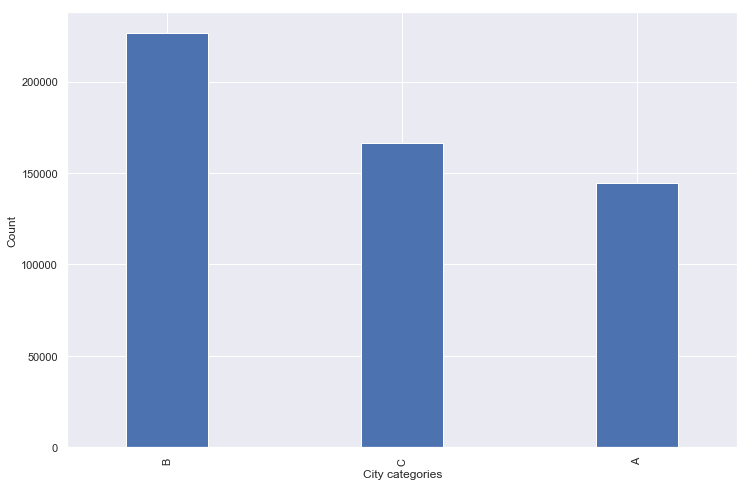

```python
plt.figure(figsize=(12,8))
df['City_Category'].value_counts().plot.bar(width=0.35,color='b')
plt.ylabel('Count')
plt.xlabel('City categories')
plt.show()
```

**Observations:**

- City B has recorded highest purchase on black friday.
- City A has mininum purchase as compared to others.

### 2. Top 5 selling products

#### Creating a dataframe with top 5 products with highest total sum

```python
df_top_5 = df.groupby(['Product_ID'],as_index = False)['Purchase'].sum().sort_values(by='Purchase',ascending=False).head(5)
```

#### Convert price column to millions

```python
df_top_5['Purchase']= (df_top_5['Purchase']/1000000)
```

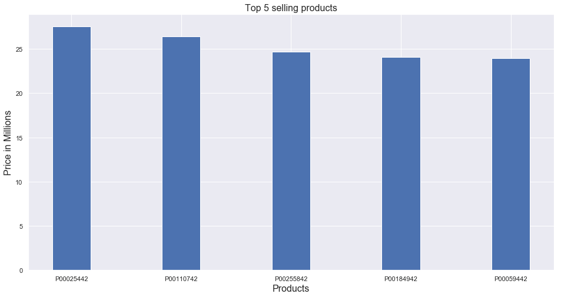

```python
plt.figure(figsize=(16,8))
y=df_top_5['Purchase']
x = df_top_5['Product_ID']
plt.bar(x,y,width=0.35)
plt.xlabel('Products', fontsize=16)
plt.ylabel('Price in Millions', fontsize=16)
plt.title('Top 5 selling products', fontsize=16)
```

**Observations:**

### 3. Age group purchase distribution

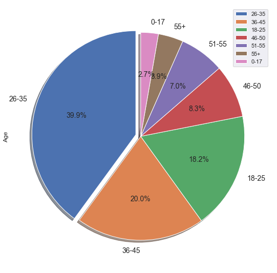

```python
plt.figure(figsize=(20,10))
# plot chart
ax1 = plt.subplot(121, aspect='equal')
df['Age'].value_counts().plot(kind='pie', ax=ax1, autopct='%1.1f%%',startangle=90,legend=True,fontsize=14,shadow=True,explode=(0.05, 0, 0, 0, 0, 0, 0))
```

**Above figure shows that age group 26-35 has done more shopping on black friday**

### 4. Total number of purchase done by Female and Male

```python
df_gender=df.groupby(['Gender'],as_index=False)['Purchase'].sum().set_index(['Gender'])
```

#### Convert Price to Millions

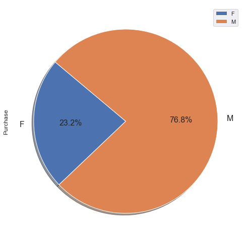

```python
plt.figure(figsize=(18,9))
# plot chart
ax1 = plt.subplot(121, aspect='equal')
df_gender['Purchase'].plot(kind='pie', ax=ax1, autopct='%1.1f%%',startangle=140,legend=True,fontsize=16,shadow=True)
```

**Observations:**

- Male users have done 76.8% of shopping.
- Suprisingly male have spent more compared to female.

### 5. Top 10 customers with hishest purchase

```python
df_top_10 = (df.groupby(['User_ID'],as_index = False)['Purchase'].sum().sort_values(by='Purchase',ascending=False).head(10))
df_top_10['Purchase'] = df_top_10['Purchase']/1000000
df_top_10= df_top_10.set_index('User_ID')
```

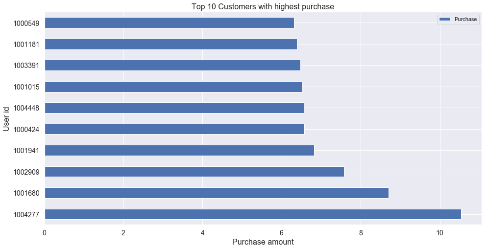

```python
df_top_10.plot.barh(legend='True',figsize=(16,8),fontsize=14)
plt.xlabel('Purchase amount', fontsize=16)
plt.ylabel('User id', fontsize=16)
plt.title('Top 10 Customers with highest purchase', fontsize=16)
```

**Observations:**

- User 1004277 has done highest purchase.

### 6. Total purchase basesd on residency duration

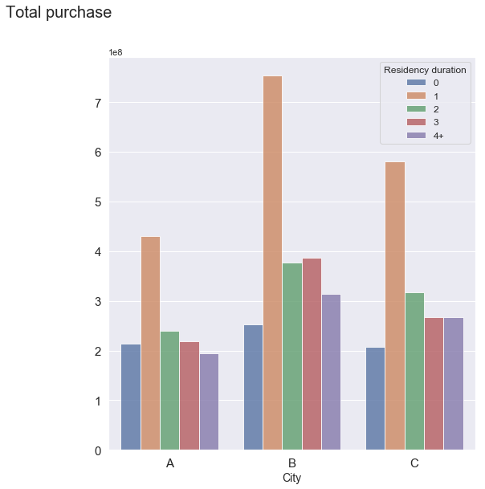

```python
df_purchase_by_City_Stay = df.groupby(['City_Category','Stay_In_Current_City_Years']).agg({'Purchase':np.sum}).reset_index()
fig = plt.figure(figsize=(18,9))
fig.suptitle('Total purchase',fontsize=20)
plt.subplot(122)
sns.barplot('City_Category','Purchase',hue='Stay_In_Current_City_Years',data=df_purchase_by_City_Stay,alpha = 0.8)
plt.xlabel('City',fontsize=14)
plt.ylabel('')
plt.legend(title='Residency duration',frameon=True,fontsize=12,loc=1)
plt.tick_params(labelsize=15)
```

**Observation:**

- Above graph shows people staying since 1 year had done more purchase compared to others

### 7. Standard deviation of the Purchase variable

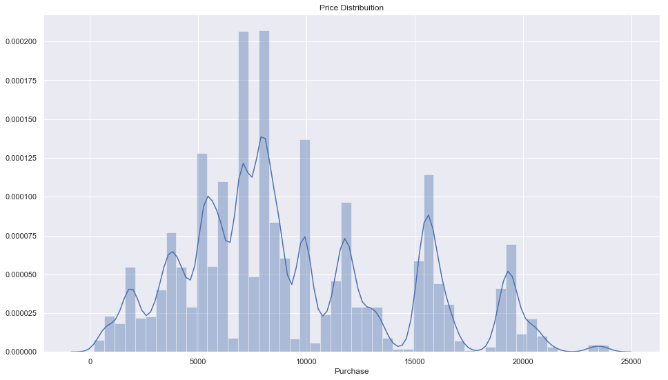

```python
plt.figure(figsize = (16, 9))
plt.title('Price Distribuition')
sns.distplot(df['Purchase'])
plt.show()
```

**Observation:**

- Grpah shows standard deviation of purchase feature , its high between 5000 to 10000.

## 2.5 Preliminary obeservation

**The following are the preliminary observations done from the black friday data of retail store. These observations are inferred from the data visualization and analysis.**

```
1.City B has more sell comapred to other 2 cities.
2.Top 5 selling products has generated purchase around 25 millions.
3.Age group 26-35 has done more purchasing (39.9%) compared to other age groups
4.Out of total purchase done male customer has done 76.8% shopping on black friday.
5.Residents who are new (1 years) have done more shopping.
```

# 3. Conclusion

**In this way above 2 data sets can be visualized and inferences can be made**

# 4. References

https://matplotlib.org/

https://pandas.pydata.org/

https://www.kaggle.com/budincsevity/szeged-weather

https://www.kaggle.com/mehdidag/black-friday

https://sourceforge.net/p/jupiter/wiki/markdown_syntax/

http://mathworld.wolfram.com/